← Back to ML Fundamentals • Week 3 of 0–15

# Week 3 — ML Fundamentals

[Open in Colab](https://colab.research.google.com/github/sanketn26/learn-ml/blob/main/notebooks/week-03-saas.ipynb) [Open in VS Code](https://vscode.dev/github/sanketn26/learn-ml/blob/main/notebooks/week-03-saas.ipynb) Open in Jupyter [Download .ipynb](https://raw.githubusercontent.com/sanketn26/learn-ml/main/notebooks/week-03-saas.ipynb)

### 📝 How to Run This Notebook Locally

**1. Clone the repository:**  
`git clone https://github.com/sanketn26/learn-ml.git && cd learn-ml`

**2. Set up environment:**  
`python3 -m venv venv && source venv/bin/activate`  
`pip install jupyter notebook`

**3. Install course dependencies:**  
`pip install numpy pandas scikit-learn matplotlib scipy seaborn`  
`pip install torch`

**4. Open the notebook:**  
`jupyter notebook notebooks/week-03-saas.ipynb`

# Week 3 — Charts That Change a Decision

**Course:** Applied ML Foundations for SaaS Analytics  
**Who this is for:** Engineers who will paste a chart into Slack or a board deck. Not a design class.

## 🎯 What you will be able to do

- Pick a chart the way you pick a data structure — by the *question*
- Build a one-page CloudWave dashboard that actually renders
- Read a cohort heatmap without being fooled by “new customers look loyal”
- Spot a dishonest chart (truncated axis, rainbow pie)

**Think of it like… picking an API response shape.**

A line chart is a time series. A bar chart is a group-by. A scatter is a join between two metrics. A heatmap is a group-by on *two* keys. A pie chart is an unreadable JSON blob with a color theme.

```python
%matplotlib inline
from pathlib import Path
import sys

import numpy as np
import pandas as pd
import matplotlib.pyplot as plt

# Make the shared style kit importable whether you launch from notebooks/ or repo root
for _p in [Path.cwd(), Path.cwd() / "notebooks", Path.cwd().parent]:
    if (_p / "course_style.py").exists():
        sys.path.insert(0, str(_p))
        break

from course_style import apply_style, setup_plots, find_data_dir

apply_style()
setup_plots()
DATA = find_data_dir()
print(f"Data folder: {DATA}")
print("Laptop mode: no GPU required. Models use a sample so each week finishes in a few minutes on CPU.")

import seaborn as sns
sns.set_theme(style='whitegrid')
```

```
Data folder: /Users/sanketnaik/workspace/learn-ml/data
Laptop mode: no GPU required. Models use a sample so each week finishes in a few minutes on CPU.
```

## 🏢 Scenario — one page for the CFO

Your CFO wants, on one screen:

1. Is churn getting worse?
2. Which plan is the leak?
3. Do engaged customers stay?
4. Do older signup cohorts retain?

**Visual cue — chart chooser**

**Trend over time** → line. **Compare categories** → bar. **Relationship** → scatter. **Two categorical axes + a rate** → heatmap. **Distribution** → histogram or box. **Share of 100%** → still a bar, not a pie (people cannot compare slice angles).

## Why not a pie chart

```
Pie:     [/////####......]   which slice is bigger — #### or .....?
Bar:     Pro         ████
         Starter     ██████
         Free        ████████████
```

If the point is “free is the biggest bucket,” a sorted bar wins in 200ms of eye time.

[output not shown]

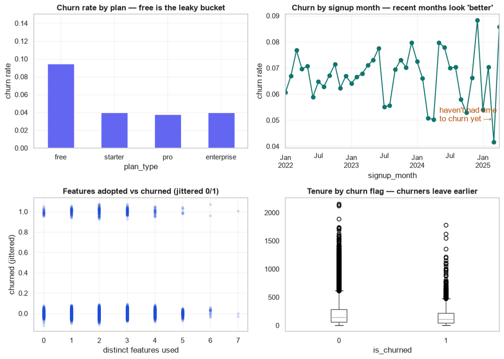

```python
subs = pd.read_csv(DATA / "subscriptions.csv", parse_dates=["signup_date", "churn_date"])
usage = pd.read_csv(DATA / "feature_usage.csv")

subs["signup_month"] = subs["signup_date"].dt.to_period("M").dt.to_timestamp()

usage_by_user = usage.groupby("user_id").agg(
    total_usage=("usage_count", "sum"),
    features_adopted=("feature_name", "nunique"),
).reset_index()
df = subs.merge(usage_by_user, on="user_id", how="left")
df["total_usage"] = df["total_usage"].fillna(0)
df["features_adopted"] = df["features_adopted"].fillna(0)

# 1) churn by plan
churn_plan = df.groupby("plan_type")["is_churned"].mean().reindex(
    ["free", "starter", "pro", "enterprise"]
)

# 2) churn by signup month (careful: recent months have had less time to churn)
churn_month = df.groupby("signup_month")["is_churned"].mean()

# 3) engagement vs outcome
sample = df.sample(min(4000, len(df)), random_state=7)

fig, axes = plt.subplots(2, 2, figsize=(11, 8))

churn_plan.plot(kind="bar", ax=axes[0, 0], color="#6366f1", rot=0)
axes[0, 0].set_title("Churn rate by plan — free is the leaky bucket")
axes[0, 0].set_ylabel("churn rate")
axes[0, 0].set_ylim(0, 0.15)

churn_month.plot(ax=axes[0, 1], marker="o", color="#0f766e")
axes[0, 1].set_title("Churn by signup month — recent months look 'better'")
axes[0, 1].set_ylabel("churn rate")
axes[0, 1].annotate("haven't had time\nto churn yet →",
                    xy=(0.72, 0.2), xycoords="axes fraction", color="#b45309")

axes[1, 0].scatter(sample["features_adopted"], sample["is_churned"]
                   + np.random.default_rng(0).normal(0, 0.03, len(sample)),
                   alpha=0.15, s=12, c="#1d4ed8")
axes[1, 0].set_title("Features adopted vs churned (jittered 0/1)")
axes[1, 0].set_xlabel("distinct features used")
axes[1, 0].set_ylabel("churned (jittered)")

# 4) tenure distribution by outcome
df.boxplot(column="tenure_days", by="is_churned", ax=axes[1, 1], grid=False)
axes[1, 1].set_title("Tenure by churn flag — churners leave earlier")
axes[1, 1].set_xlabel("is_churned")
axes[1, 1].get_figure().suptitle("")

plt.tight_layout()
plt.show()
```

## Cohort heatmap — the chart that fools smart people

**30-day retention** for the cohort that signed up *last week* is not comparable to the cohort from a year ago. Young cohorts have not had time to die.

**Watch out**

A heatmap that is bright-green in the bottom rows (newest signups) often means *they are still new*, not that you suddenly built a better product. Gray-out cells that have not reached that age.

**Engineer mental model**

A cohort chart is a two-key group-by: `(signup_month, age_bucket) → retained_rate`. Same as a SQL cube. The visual is optional; the grain is not.

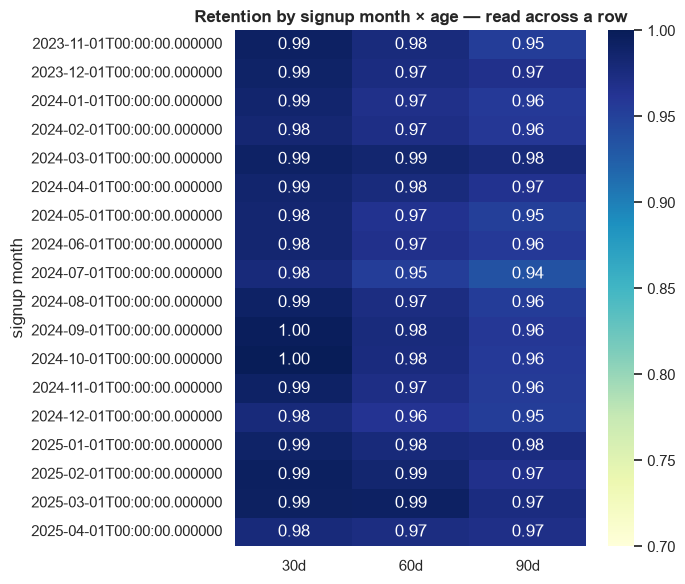

```
Read a row: of people who signed up that month and are old enough,
what fraction lived at least 30 / 60 / 90 days.
```

```python
# Simple age-at-observation proxy using tenure_days + churn
# Active customers: tenure is how long they have lived so far
# Churned customers: tenure is how long they lived before leaving

def retention_at(days: int, frame: pd.DataFrame) -> pd.Series:
    # Eligible = old enough to have reached `days`.
    # Still-active users with short tenure have not had time to churn — drop them.
    eligible = frame.copy()
    too_young = (eligible["is_churned"] == 0) & (eligible["tenure_days"] < days)
    eligible = eligible[~too_young]
    retained = eligible["tenure_days"] >= days
    return eligible.assign(retained=retained).groupby("signup_month")["retained"].mean()

months = sorted(df["signup_month"].dropna().unique())
ages = [30, 60, 90]
heat = pd.DataFrame({f"{d}d": retention_at(d, df) for d in ages})

fig, ax = plt.subplots(figsize=(7, 6))
sns.heatmap(heat.tail(18), annot=True, fmt=".2f", cmap="YlGnBu", ax=ax, vmin=0.7, vmax=1)
ax.set_title("Retention by signup month × age — read across a row")
ax.set_ylabel("signup month")
plt.tight_layout()
plt.show()

print("Read a row: of people who signed up that month and are old enough,")
print("what fraction lived at least 30 / 60 / 90 days.")
```

## Bad chart vs honest chart

Same data. One lies with a truncated axis.

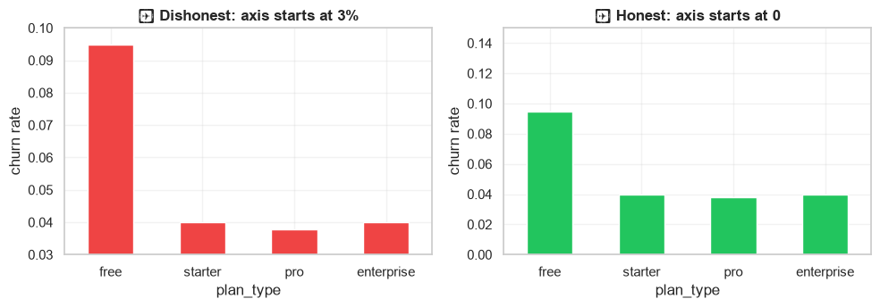

[output not shown]

```python
fig, axes = plt.subplots(1, 2, figsize=(10, 3.6))
churn_plan.plot(kind="bar", ax=axes[0], color="#ef4444", rot=0)
axes[0].set_ylim(0.03, 0.10)
axes[0].set_title("❌ Dishonest: axis starts at 3%")
axes[0].set_ylabel("churn rate")

churn_plan.plot(kind="bar", ax=axes[1], color="#22c55e", rot=0)
axes[1].set_ylim(0, 0.15)
axes[1].set_title("✅ Honest: axis starts at 0")
axes[1].set_ylabel("churn rate")
plt.tight_layout()
plt.show()

print("The left chart makes starter vs pro look like a crisis.")
print("The right chart says: all paid plans are similar; free is different.")
```

**Ship / don’t ship**

- **Slack / debugging:** default Pandas/Seaborn is fine. Label axes. Start bars at 0.
- **Board deck:** one sentence title that is the insight, not the chart type. “Free churn is 2× paid,” not “Churn by plan.”
- **Never:** dual axes, 3-D bars, pie-of-pies, rainbow on unordered categories.

## ✍️ Exercises

**1. Adoption curve.** For users with a `signup_date`, plot average `features_adopted` by `plan_type` as a bar. Annotate the winner.

**2. Region bars.** Most-common region per user from events, then churn rate by region. Horizontal bars, sorted.

**3. Honest title.** Rebuild the plan-churn bar so the title is a claim (“Free churn is ~2× paid”) and the y-axis starts at 0.

## 🤔 Reflection

1. A region’s churn *looks* high. List five non-product reasons (pricing, support hours, competitor, sales quality, data bug).
2. Feature adoption correlates with lower churn. Draw the causation arrow both ways.
3. Which one chart would you send the CEO, and which sentence sits above it?

## 🔗 Next week

The CFO asks: “16% vs 20% churn — is that real?” We will answer without turning you into a statistician.

← Previous Week Back to ML Fundamentals Next Week →